# VARモデル

##### 『Advanced Python 時系列解析』より

```python
import statsmodels.api as sm
import pandas as pd
```

## サンプルデータ用意

```python
df_data = sm.datasets.macrodata.load_pandas().data
df_data.head()
```

|  | year | quarter | realgdp | realcons | realinv | realgovt | realdpi | cpi | m1 | tbilrate | unemp | pop | infl | realint |
| --- | --- | --- | --- | --- | --- | --- | --- | --- | --- | --- | --- | --- | --- | --- |
| 0 | 1959.0 | 1.0 | 2710.349 | 1707.4 | 286.898 | 470.045 | 1886.9 | 28.98 | 139.7 | 2.82 | 5.8 | 177.146 | 0.00 | 0.00 |
| 1 | 1959.0 | 2.0 | 2778.801 | 1733.7 | 310.859 | 481.301 | 1919.7 | 29.15 | 141.7 | 3.08 | 5.1 | 177.830 | 2.34 | 0.74 |
| 2 | 1959.0 | 3.0 | 2775.488 | 1751.8 | 289.226 | 491.260 | 1916.4 | 29.35 | 140.5 | 3.82 | 5.3 | 178.657 | 2.74 | 1.09 |
| 3 | 1959.0 | 4.0 | 2785.204 | 1753.7 | 299.356 | 484.052 | 1931.3 | 29.37 | 140.0 | 4.33 | 5.6 | 179.386 | 0.27 | 4.06 |
| 4 | 1960.0 | 1.0 | 2847.699 | 1770.5 | 331.722 | 462.199 | 1955.5 | 29.54 | 139.6 | 3.50 | 5.2 | 180.007 | 2.31 | 1.19 |

- realgdb：実質GPD
- realcons：実質個人消費支出
- realivn：実質設備投資

#### 上記３変数を用いて、VARモデルを作成

```python
# indexを年月日に変換
df_data.index = pd.date_range('1959', periods=51*4-1, freq='Q')

y = df_data[['realgdp', 'realcons', 'realinv']]
```

```python
y
```

|  | realgdp | realcons | realinv |
| --- | --- | --- | --- |
| 1959-03-31 | 2710.349 | 1707.4 | 286.898 |
| 1959-06-30 | 2778.801 | 1733.7 | 310.859 |
| 1959-09-30 | 2775.488 | 1751.8 | 289.226 |
| 1959-12-31 | 2785.204 | 1753.7 | 299.356 |
| 1960-03-31 | 2847.699 | 1770.5 | 331.722 |
| ... | ... | ... | ... |
| 2008-09-30 | 13324.600 | 9267.7 | 1990.693 |
| 2008-12-31 | 13141.920 | 9195.3 | 1857.661 |
| 2009-03-31 | 12925.410 | 9209.2 | 1558.494 |
| 2009-06-30 | 12901.504 | 9189.0 | 1456.678 |
| 2009-09-30 | 12990.341 | 9256.0 | 1486.398 |

203 rows × 3 columns

## ADF検定により、各変数が単位根過程であるか確認

```python
from statsmodels.tsa import stattools
```

```python
# ADF検定
ctt_realgdp = stattools.adfuller(y.realgdp, regression='ctt')
ctt_realcons = stattools.adfuller(y.realcons, regression='ctt')
ctt_realinv = stattools.adfuller(y.realinv, regression='ctt')

print('ctt realgdp:')
print(ctt_realgdp)
print('ctt realcons:')
print(ctt_realcons)
print('ctt realinv:')
print(ctt_realinv)
```

```
ctt realgdp:
(-2.231625563440861, 0.7145024076165514, 12, 190, {'1%': -4.433161444379647, '5%': -3.8638358600379066, '10%': -3.572676939641347}, 2030.9096153927815)
ctt realcons:
(-3.0087027982374197, 0.2910505147103153, 3, 199, {'1%': -4.430309046694293, '5%': -3.8623972900169137, '10%': -3.5717916732395594}, 1787.2221616792606)
ctt realinv:
(-1.63192154661618, 0.9226177810403438, 3, 199, {'1%': -4.430309046694293, '5%': -3.8623972900169137, '10%': -3.5717916732395594}, 1945.7305980020012)
```

- 2つ目がp値
- 3つともp値が高く３変数すべてが単位根過程であることがわかる

## 定常過程にするために２次の階差をとり、再度、単位根検定を実施

```python
# ２次の階差
y_diff = y.diff().diff().dropna()
```

```python
# ADF検定
ctt_realgdp_diff = stattools.adfuller(y_diff.realgdp, regression='ctt')
ctt_realcons_diff = stattools.adfuller(y_diff.realcons, regression='ctt')
ctt_realinv_diff = stattools.adfuller(y_diff.realinv, regression='ctt')

print('ctt realgdp_diff:')
print(ctt_realgdp_diff)
print('ctt realcons_diff:')
print(ctt_realcons_diff)
print('ctt realinv_diff:')
print(ctt_realinv_diff)
```

```
ctt realgdp_diff:
(-5.7307111708532315, 4.5129005984889235e-05, 14, 186, {'1%': -4.434519413562635, '5%': -3.864520481428023, '10%': -3.5730981406825575}, 2025.6464949041335)
ctt realcons_diff:
(-16.930875191757355, 7.34261860797005e-25, 1, 199, {'1%': -4.430309046694293, '5%': -3.8623972900169137, '10%': -3.5717916732395594}, 1792.6484152650387)
ctt realinv_diff:
(-8.24609938470198, 8.39040862417975e-11, 7, 193, {'1%': -4.432180562792867, '5%': -3.8633412462204713, '10%': -3.5723725968816216}, 1936.5507934933223)
```

- ３つすべてp値が閾値より小さいので、２次の階差をとることで単位根過程でなくなった

## VARモデル作成

```python
from statsmodels.tsa.api import VAR
```

```python
# モデル作成
model_diff = VAR(y_diff)
```

```python
# ラグ探索
model_diff.select_order(10).summary()
```

VAR Order Selection (* highlights the minimums)

|  | AIC | BIC | FPE | HQIC |
| --- | --- | --- | --- | --- |
| 0 | 22.00 | 22.05 | 3.570e+09 | 22.02 |
| 1 | 21.20 | 21.40 | 1.607e+09 | 21.28 |
| 2 | 20.73 | 21.09* | 1.007e+09 | 20.87 |
| 3 | 20.61 | 21.12 | 8.953e+08 | 20.82* |
| 4 | 20.58 | 21.25 | 8.701e+08 | 20.85 |
| 5 | 20.55 | 21.37 | 8.406e+08 | 20.88 |
| 6 | 20.59 | 21.56 | 8.748e+08 | 20.98 |
| 7 | 20.61 | 21.74 | 8.983e+08 | 21.07 |
| 8 | 20.50 | 21.77 | 8.009e+08 | 21.01 |
| 9 | 20.49* | 21.92 | 7.995e+08* | 21.07 |
| 10 | 20.55 | 22.14 | 8.505e+08 | 21.19 |

- AICでは、次数9のときに最適
- しかし、statsmodelsのVARモデルには自動で最適なラグの次数を選択してくれる機能があるので、それを利用する

```python
# AIC基準で最適なハイパーパラメータを選択したモデルのあてはめ
result_diff = model_diff.fit(maxlags=10, ic='aic')
```

```python
# あてはめ結果
result_diff.summary()
```

```
  Summary of Regression Results
==================================
Model:                         VAR
Method:                        OLS
Date:           Mon, 08, Nov, 2021
Time:                     22:34:12
--------------------------------------------------------------------
No. of Equations:         3.00000    BIC:                    21.9079
Nobs:                     192.000    HQIC:                   21.0600
Log likelihood:          -2699.66    FPE:                7.91212e+08
AIC:                      20.4828    Det(Omega_mle):     5.25930e+08
--------------------------------------------------------------------
Results for equation realgdp
==============================================================================
                 coefficient       std. error           t-stat            prob
------------------------------------------------------------------------------
const               0.352231         3.570180            0.099           0.921
L1.realgdp         -1.247885         0.162953           -7.658           0.000
L1.realcons         1.084603         0.212161            5.112           0.000
L1.realinv          0.348446         0.200801            1.735           0.083
L2.realgdp         -1.113375         0.227777           -4.888           0.000
L2.realcons         1.458917         0.274373            5.317           0.000
L2.realinv          0.214894         0.256314            0.838           0.402
L3.realgdp         -1.201289         0.264611           -4.540           0.000
L3.realcons         1.643437         0.313106            5.249           0.000
L3.realinv          0.258869         0.297026            0.872           0.383
L4.realgdp         -1.158100         0.287695           -4.025           0.000
L4.realcons         1.540831         0.335685            4.590           0.000
L4.realinv          0.495671         0.319816            1.550           0.121
L5.realgdp         -1.114796         0.302466           -3.686           0.000
L5.realcons         1.198746         0.343534            3.489           0.000
L5.realinv          0.410151         0.331977            1.235           0.217
L6.realgdp         -1.140106         0.304264           -3.747           0.000
L6.realcons         1.430550         0.342515            4.177           0.000
L6.realinv          0.520990         0.331061            1.574           0.116
L7.realgdp         -1.169328         0.285298           -4.099           0.000
L7.realcons         1.446455         0.334971            4.318           0.000
L7.realinv          0.669876         0.312499            2.144           0.032
L8.realgdp         -0.935261         0.254398           -3.676           0.000
L8.realcons         0.921095         0.305941            3.011           0.003
```

[output cut: 64 more lines]

```
L7.realcons         0.613108         0.240195            2.553           0.011
L7.realinv          0.069317         0.224081            0.309           0.757
L8.realgdp         -0.322333         0.182419           -1.767           0.077
L8.realcons         0.336192         0.219378            1.532           0.125
L8.realinv         -0.084225         0.199292           -0.423           0.673
L9.realgdp         -0.215587         0.129757           -1.661           0.097
L9.realcons         0.200933         0.170649            1.177           0.239
L9.realinv          0.080880         0.147233            0.549           0.583
==============================================================================

Correlation matrix of residuals
             realgdp  realcons   realinv
realgdp     1.000000  0.516204  0.692511
realcons    0.516204  1.000000 -0.029880
realinv     0.692511 -0.029880  1.000000
```

- summaryより、各変数に対する係数が9個づつあるので、ラグの次数９が選択されたことがわかる

## 予測誤差分散分解（FEVD)

- FEVDを用いて、i次点先予測時の誤差の起因の程度を分解する
- 誤差の起因の程度を分解することで、各変数に対して他のどの変数がどの程度の説明力を持っているかを知ることができる

```python
fevd_diff = result_diff.fevd(4) # ３次点先までの誤差の起因
fevd_diff.summary()
```

```
FEVD for realgdp
      realgdp  realcons   realinv
0    1.000000  0.000000  0.000000
1    0.892571  0.096255  0.011175
2    0.887540  0.097189  0.015271
3    0.883109  0.095237  0.021655

FEVD for realcons
      realgdp  realcons   realinv
0    0.266466  0.733534  0.000000
1    0.283437  0.697520  0.019043
2    0.282337  0.698602  0.019061
3    0.281744  0.698428  0.019828

FEVD for realinv
      realgdp  realcons   realinv
0    0.479571  0.204551  0.315877
1    0.289142  0.461684  0.249174
2    0.292990  0.459687  0.247323
3    0.305582  0.449273  0.245145
```

- 3次点先のFEVDの数値を見ると、realgdp(実質GDP)およびrealcons(実質個人消費支出)において、それぞれ0.883、0.698と自身のウェイトが高いが、realinv(実質設備投資)では、realgdpが0.305、relaconsが0.449となっており、realinvの予測誤差に対してrealgdpとrealconsの説明力が相対的に大きいことがわかる

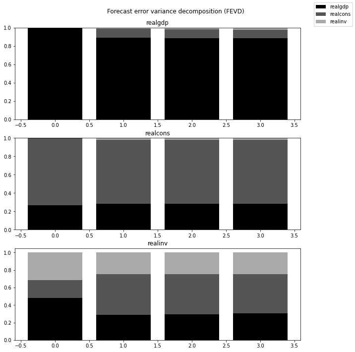

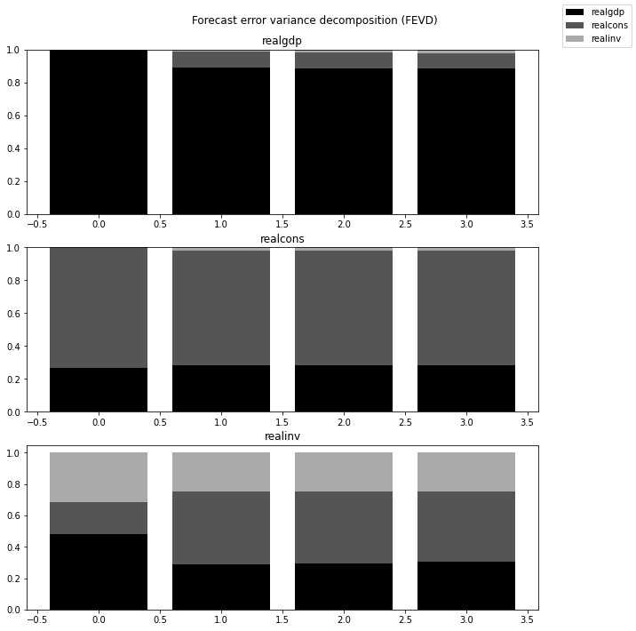

```python
# FEVDの可視化
result_diff.fevd(4).plot()
```